# Data Analysis - Lab-2

1. Create two matrices from the given set of numbers: X1 = {2,3,7,1,6,2,3,5,1} and X2 = {3,2,9,0,7,8,5,8,2}

```r
X1 <- matrix(c(2,3,7,1,6,2,3,5,1), nrow=3, ncol=3)
X2 <- matrix(c(3,2,9,0,7,8,5,8,2), nrow=3, ncol=3)
X1
```

```
##      [,1] [,2] [,3]
## [1,]    2    1    3
## [2,]    3    6    5
## [3,]    7    2    1
```

```r
X2
```

```
##      [,1] [,2] [,3]
## [1,]    3    0    5
## [2,]    2    7    8
## [3,]    9    8    2
```

2. Find the matrix product.

```r
X3 <- X1 %*% X2
X3
```

```
##      [,1] [,2] [,3]
## [1,]   35   31   24
## [2,]   66   82   73
## [3,]   34   22   53
```

3. Find the inverse of the matrix and prove that it is correct.

```r
solve(X3)
```

```
##             [,1]         [,2]         [,3]
## [1,]  0.08472480 -0.034477427  0.009121831
## [2,] -0.03141620  0.032127396 -0.030024737
## [3,] -0.04131107  0.008781694  0.025479283
```

```r
iX3 <- solve(X3)
X3 %*% iX3
```

```
##               [,1]          [,2] [,3]
## [1,]  1.000000e+00 -2.775558e-17    0
## [2,] -4.440892e-16  1.000000e+00    0
## [3,]  0.000000e+00  5.551115e-17    1
```

4. Load the Animals data set from the “MASS” package.

```r
library(MASS)
head(Animals)
```

```
##                     body brain
## Mountain beaver     1.35   8.1
## Cow               465.00 423.0
## Grey wolf          36.33 119.5
## Goat               27.66 115.0
## Guinea pig          1.04   5.5
## Dipliodocus     11700.00  50.0
```

5. Find the correlation coefficient of brain and body in this data set and comment on the relation between them.

```r
body <- Animals$body
brain <- Animals$brain
cor(brain, body)
```

```
## [1] -0.005341163
```

```r
cor(Animals)
```

```
##               body        brain
## body   1.000000000 -0.005341163
## brain -0.005341163  1.000000000
```

6. Load USArrests data set.

Load USArrests and run a few functions to review dataset - head, names, list data.

```r
data(USArrests)
head(USArrests)
```

```
##            Murder Assault UrbanPop Rape
## Alabama      13.2     236       58 21.2
## Alaska       10.0     263       48 44.5
## Arizona       8.1     294       80 31.0
## Arkansas      8.8     190       50 19.5
## California    9.0     276       91 40.6
## Colorado      7.9     204       78 38.7
```

```r
names(USArrests)
```

```
## [1] "Murder"   "Assault"  "UrbanPop" "Rape"
```

```r
USArrests
```

```
##                Murder Assault UrbanPop Rape
## Alabama          13.2     236       58 21.2
## Alaska           10.0     263       48 44.5
## Arizona           8.1     294       80 31.0
## Arkansas          8.8     190       50 19.5
## California        9.0     276       91 40.6
## Colorado          7.9     204       78 38.7
## Connecticut       3.3     110       77 11.1
## Delaware          5.9     238       72 15.8
## Florida          15.4     335       80 31.9
## Georgia          17.4     211       60 25.8
## Hawaii            5.3      46       83 20.2
## Idaho             2.6     120       54 14.2
## Illinois         10.4     249       83 24.0
## Indiana           7.2     113       65 21.0
## Iowa              2.2      56       57 11.3
## Kansas            6.0     115       66 18.0
## Kentucky          9.7     109       52 16.3
## Louisiana        15.4     249       66 22.2
## Maine             2.1      83       51  7.8
## Maryland         11.3     300       67 27.8
## Massachusetts     4.4     149       85 16.3
## Michigan         12.1     255       74 35.1
## Minnesota         2.7      72       66 14.9
## Mississippi      16.1     259       44 17.1
## Missouri          9.0     178       70 28.2
## Montana           6.0     109       53 16.4
## Nebraska          4.3     102       62 16.5
## Nevada           12.2     252       81 46.0
## New Hampshire     2.1      57       56  9.5
## New Jersey        7.4     159       89 18.8
## New Mexico       11.4     285       70 32.1
## New York         11.1     254       86 26.1
## North Carolina   13.0     337       45 16.1
## North Dakota      0.8      45       44  7.3
## Ohio              7.3     120       75 21.4
## Oklahoma          6.6     151       68 20.0
## Oregon            4.9     159       67 29.3
## Pennsylvania      6.3     106       72 14.9
## Rhode Island      3.4     174       87  8.3
## South Carolina   14.4     279       48 22.5
## South Dakota      3.8      86       45 12.8
## Tennessee        13.2     188       59 26.9
## Texas            12.7     201       80 25.5
## Utah              3.2     120       80 22.9
## Vermont           2.2      48       32 11.2
## Virginia          8.5     156       63 20.7
## Washington        4.0     145       73 26.2
## West Virginia     5.7      81       39  9.3
## Wisconsin         2.6      53       66 10.8
## Wyoming           6.8     161       60 15.6
```

Comment on the distribution of the variables. Is there any relation between UrbanPop and three crimes?

```r
summary(USArrests)
```

```
##      Murder          Assault         UrbanPop          Rape
##  Min.   : 0.800   Min.   : 45.0   Min.   :32.00   Min.   : 7.30
##  1st Qu.: 4.075   1st Qu.:109.0   1st Qu.:54.50   1st Qu.:15.07
##  Median : 7.250   Median :159.0   Median :66.00   Median :20.10
##  Mean   : 7.788   Mean   :170.8   Mean   :65.54   Mean   :21.23
##  3rd Qu.:11.250   3rd Qu.:249.0   3rd Qu.:77.75   3rd Qu.:26.18
##  Max.   :17.400   Max.   :337.0   Max.   :91.00   Max.   :46.00
```

```r
cor(USArrests)
```

```
##              Murder   Assault   UrbanPop      Rape
## Murder   1.00000000 0.8018733 0.06957262 0.5635788
## Assault  0.80187331 1.0000000 0.25887170 0.6652412
## UrbanPop 0.06957262 0.2588717 1.00000000 0.4113412
## Rape     0.56357883 0.6652412 0.41134124 1.0000000
```

Running plot for these combinations, Murder and Assault do not appear to have a relation to UrbanPop. The distribution of plot points are scattered to the point that they do not appear to correlate to UrbanPop.

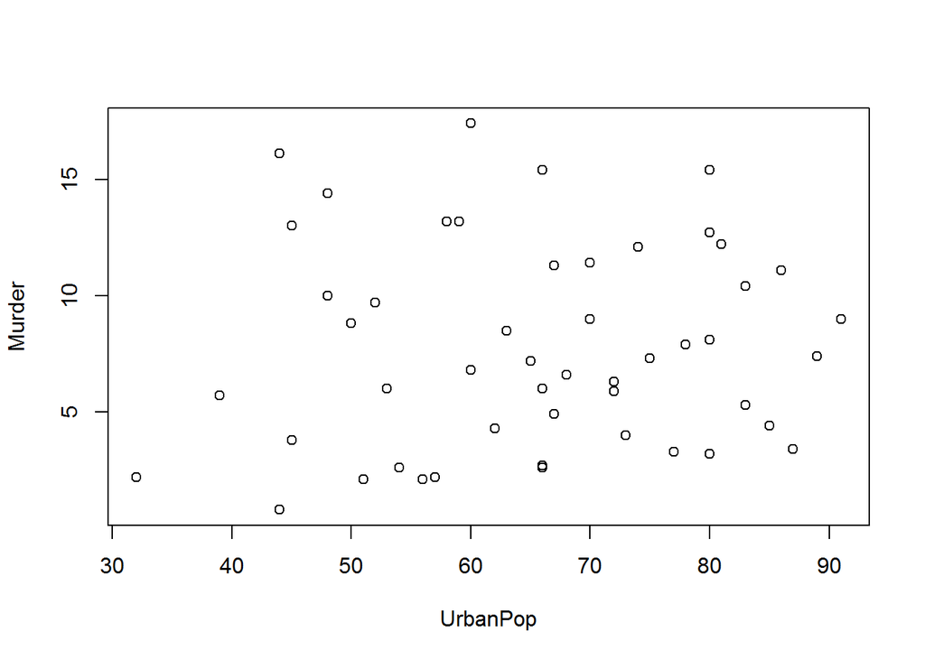

```r
with(USArrests, plot(UrbanPop, Murder))
```

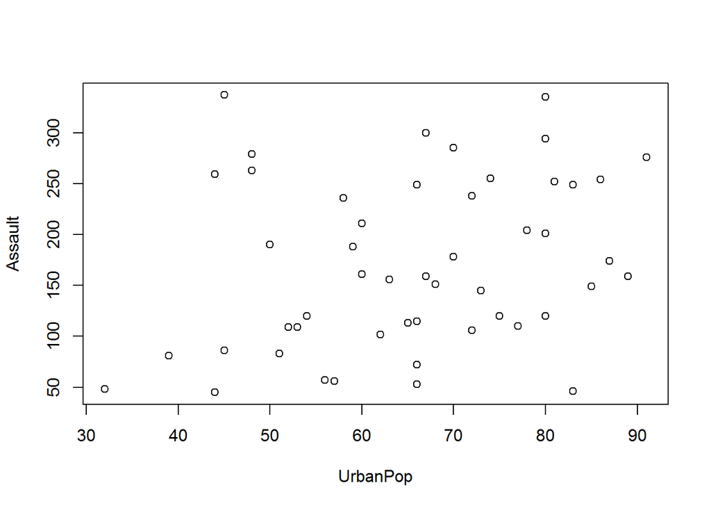

```r
with(USArrests, plot(UrbanPop, Assault))
```

Plotting Rape against UrbanPop - there are some outliers, but there does seem to be a relationship between Rape and UrbanPop. There is an indication of a correlation and more analysis could be performed.

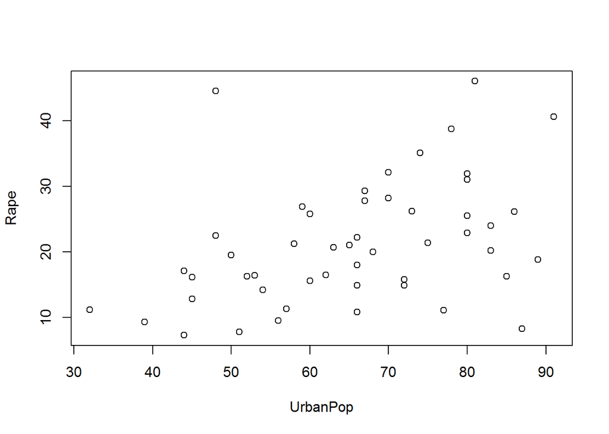

```r
with(USArrests, plot(UrbanPop, Rape))
```

7. Which states has most and least assault, murder, and rape arrests?

```r
# most and least assault
x <- which(USArrests$Assault == max(USArrests$Assault))
rownames(USArrests)[x]
```

```
## [1] "North Carolina"
```

```r
x <- which(USArrests$Assault == min(USArrests$Assault))
rownames(USArrests)[x]
```

```
## [1] "North Dakota"
```

```r
# most and least murder
x <- which(USArrests$Murder == max(USArrests$Murder))
rownames(USArrests)[x]
```

```
## [1] "Georgia"
```

```r
x <- which(USArrests$Murder == min(USArrests$Murder))
rownames(USArrests)[x]
```

```
## [1] "North Dakota"
```

```r
# most and least rape
x <- which(USArrests$Rape == max(USArrests$Rape))
rownames(USArrests)[x]
```

```
## [1] "Nevada"
```

```r
x <- which(USArrests$Rape == min(USArrests$Rape))
rownames(USArrests)[x]
```

```
## [1] "North Dakota"
```

8. List the states which have assault arrests more than median of the country.

```r
assault.median = median(USArrests$Assault)
assault.median
```

```
## [1] 159
```

```r
subset(USArrests, Assault > assault.median, select= c(UrbanPop, Assault))
```

```
##                UrbanPop Assault
## Alabama              58     236
## Alaska               48     263
## Arizona              80     294
## Arkansas             50     190
## California           91     276
## Colorado             78     204
## Delaware             72     238
## Florida              80     335
## Georgia              60     211
## Illinois             83     249
## Louisiana            66     249
## Maryland             67     300
## Michigan             74     255
## Mississippi          44     259
## Missouri             70     178
## Nevada               81     252
## New Mexico           70     285
## New York             86     254
## North Carolina       45     337
## Rhode Island         87     174
## South Carolina       48     279
## Tennessee            59     188
## Texas                80     201
## Wyoming              60     161
```

9. Which states are in the bottom 25% of murder?

```r
bottomQuartileMurderRate <- quantile(USArrests$Murder)[2]
bottomQuartileMurderRate
```

```
##   25%
## 4.075
```

```r
subset(USArrests, Murder < bottomQuartileMurderRate, select= c(UrbanPop, Murder))
```

```
##               UrbanPop Murder
## Connecticut         77    3.3
## Idaho               54    2.6
## Iowa                57    2.2
## Maine               51    2.1
## Minnesota           66    2.7
## New Hampshire       56    2.1
## North Dakota        44    0.8
## Rhode Island        87    3.4
## South Dakota        45    3.8
## Utah                80    3.2
## Vermont             32    2.2
## Washington          73    4.0
## Wisconsin           66    2.6
```

10. Which states are in the top 25% of the murder.

```r
topQuartileMurderRate <- quantile(USArrests$Murder)[4]
topQuartileMurderRate
```

```
##   75%
## 11.25
```

```r
subset(USArrests, Murder > topQuartileMurderRate, select= c(UrbanPop, Murder))
```

```
##                UrbanPop Murder
## Alabama              58   13.2
## Florida              80   15.4
## Georgia              60   17.4
## Louisiana            66   15.4
## Maryland             67   11.3
## Michigan             74   12.1
## Mississippi          44   16.1
## Nevada               81   12.2
## New Mexico           70   11.4
## North Carolina       45   13.0
## South Carolina       48   14.4
## Tennessee            59   13.2
## Texas                80   12.7
```